# Homework 3 - C++ code from R

Eunchong Kang

02/08/2022

```r
library(usethis)
library(devtools)
library(Rcpp)
library(RcppArmadillo)
library(microbenchmark)
library(MASS)

# load my package
document("../bios735")
```

```
## Writing NAMESPACE
## Writing NAMESPACE
```

```r
load_all("../bios735")
```

# Question 1 - simple Rcpp function

Write a Rcpp function named `one.or.exp` that implements the R code, `ifelse(x < 0.0, 1.0, exp(x))`, and compare its output.

```r
x <- -10:10
one.or.exp(x)
```

```
##  [1]     1.000000     1.000000     1.000000     1.000000     1.000000
##  [6]     1.000000     1.000000     1.000000     1.000000     1.000000
## [11]     1.000000     2.718282     7.389056    20.085537    54.598150
## [16]   148.413159   403.428793  1096.633158  2980.957987  8103.083928
## [21] 22026.465795
```

```r
all.equal(ifelse(x < 0.0,1.0,exp(x)), one.or.exp(x))
```

```
## [1] TRUE
```

# Question 2 - random walk in C++ and vectorized R

Write a random walk function in C++ named `randomWalk2`, and compare its output with `randomWalk1`.

1. Sample Random walk

```r
niter <- 1e4
lambda <- .01
randomWalk1 <- function(niter,lambda) {
  x <- numeric(niter)
  y <- numeric(niter)
  for (i in seq_len(niter)[-1]) {
    x[i] <- x[i-1] + lambda * (2.0 * rbinom(1,1,0.5) - 1.0)
  }
  for (i in seq_len(niter)[-1]) {
    y[i] <- y[i-1] + lambda * (2.0 * rbinom(1,1,0.5) - 1.0)
  }
  list(x=x,y=y)
}
myplot <- function(dat) {
  niter <- length(dat$x)
  plot(0,type="n",xlim=c(-2,2),ylim=c(-2,2),xlab="x",ylab="y")
  cols <- colorRampPalette(c("blue","red","orange"))(100)
  with(dat, segments(x[-niter],y[-niter],x[-1],y[-1],col=rep(cols,each=niter/100)))
}
set.seed(5)
dat1 <- randomWalk1(niter,lambda)
str(dat1)
```

```
## List of 2
##  $ x: num [1:10000] 0 -0.01 0 0.01 0 -0.01 0 0.01 0.02 0.03 ...
##  $ y: num [1:10000] 0 0.01 0 0.01 0.02 0.03 0.02 0.03 0.02 0.01 ...
```

```r
myplot(dat1)
```

[output not shown]

2. my random walk:

```r
set.seed(5)
dat2 <- randomWalk2(niter,lambda)
str(dat2)
```

```
## List of 2
##  $ x: num [1:10000] 0 -0.01 0 0.01 0 -0.01 0 0.01 0.02 0.03 ...
##  $ y: num [1:10000] 0 0.01 0 0.01 0.02 0.03 0.02 0.03 0.02 0.01 ...
```

```r
myplot(dat2)
```

[output not shown]

```r
all.equal(dat2$x, dat1$x)
```

```
## [1] TRUE
```

```r
all.equal(dat2$y, dat1$y)
```

```
## [1] TRUE
```

```r
microbenchmark(randomWalk1(niter,lambda),randomWalk2(niter,lambda),times=10)
```

```
## Unit: milliseconds
##                        expr     min        lq      mean    median        uq
##  randomWalk1(niter, lambda) 26.9781 29.313100 30.883341 29.780351 32.112802
##  randomWalk2(niter, lambda)  1.1666  1.168301  1.218591  1.188651  1.205901
##        max neval
##  39.966702    10
##   1.520901    10
```

write a vectorized version of the random walk in R named `randomWalkVectorized`, and compare its output.

3. Vectorized Random Walk

```r
randomWalkVectorized <- function(niter,lambda) {
        x <- c(0, lambda * (2.0 * rbinom(niter-1, 1, 0.5) - 1.0))
        y <- c(0, lambda * (2.0 * rbinom(niter-1, 1, 0.5) - 1.0))
        list(x=cumsum(x), y=cumsum(y))
}
```

```r
set.seed(5)
datVec <- randomWalkVectorized(niter,lambda)
str(datVec)
```

```
## List of 2
##  $ x: num [1:10000] 0 -0.01 0 0.01 0 -0.01 0 0.01 0.02 0.03 ...
##  $ y: num [1:10000] 0 0.01 0 0.01 0.02 0.03 0.02 0.03 0.02 0.01 ...
```

```r
myplot(datVec)
```

[output not shown]

```r
all.equal(datVec$x, dat1$x)
```

```
## [1] TRUE
```

```r
all.equal(datVec$y, dat1$y)
```

```
## [1] TRUE
```

```r
microbenchmark(randomWalk1(niter,lambda),randomWalkVectorized(niter,lambda),times=10)
```

```
## Unit: milliseconds
##                                 expr     min        lq      mean    median
##           randomWalk1(niter, lambda) 26.3818 28.740302 29.457301 29.462051
##  randomWalkVectorized(niter, lambda)  1.3706  1.373601  2.218781  1.386601
##         uq     max neval
##  30.384901 31.5629    10
##   1.391401  9.7349    10
```

```r
microbenchmark(randomWalk2(niter,lambda),randomWalkVectorized(niter,lambda),times=10)
```

```
## Unit: milliseconds
##                                 expr      min       lq     mean   median
##           randomWalk2(niter, lambda) 1.160301 1.166901 1.186861 1.175901
##  randomWalkVectorized(niter, lambda) 1.378201 1.380402 1.406511 1.387601
##        uq      max neval
##  1.194401 1.258901    10
##  1.440801 1.490601    10
```

# Question 3 - simple RcppArmadillo function

Write a simple RcppArmadillo function that solves $AX = b$ named `armadilloSolve`.

```r
A <- matrix(runif(12),ncol=3)
x <- matrix(runif(3),ncol=1)
b <- A %*% x
xx <- armadilloSolve(A,b)
all.equal(x, xx)
```

```
## [1] TRUE
```

# Question 4 - column-wise ridge regression

Write a function `colRidge2` which implements ridge regression.Compare the output of `colRidge2` to `colRidge1`.

```r
set.seed(1)
n <- 100
Y <- matrix(rnorm(n*20),nrow=20)
X <- scale(matrix(rnorm(20*2),ncol=2))
lambda <- runif(n,.1,2)

colRidge1 <- function(Y, X, lambda) {
  df <- as.data.frame(X)
  n <- ncol(Y)
  beta <- matrix(nrow=2,ncol=n)
  stopifnot(length(lambda) == n)
  for (j in seq_len(n)) {
    beta[,j] <- coef(lm.ridge(Y[,j] ~ 0 + V1 + V2, data=df, lambda=lambda[j]))
  }
  beta
}
beta1 <- colRidge1(Y, X, lambda)
beta1[,1:5]
```

```
##             [,1]         [,2]       [,3]       [,4]       [,5]
## [1,] -0.12682942  0.008888149 0.31188903  0.0205888 0.17143261
## [2,]  0.07738113 -0.102197878 0.02560331 -0.4147540 0.01577768
```

```r
beta2 <- colRidge2(Y, X, lambda)
beta2[,1:5]
```

```
##            [,1]         [,2]       [,3]        [,4]      [,5]
## [1,] -0.1264175  0.008740393 0.31072209  0.02002521 0.1711246
## [2,]  0.0770407 -0.101904019 0.02601971 -0.41356503 0.0158899
```

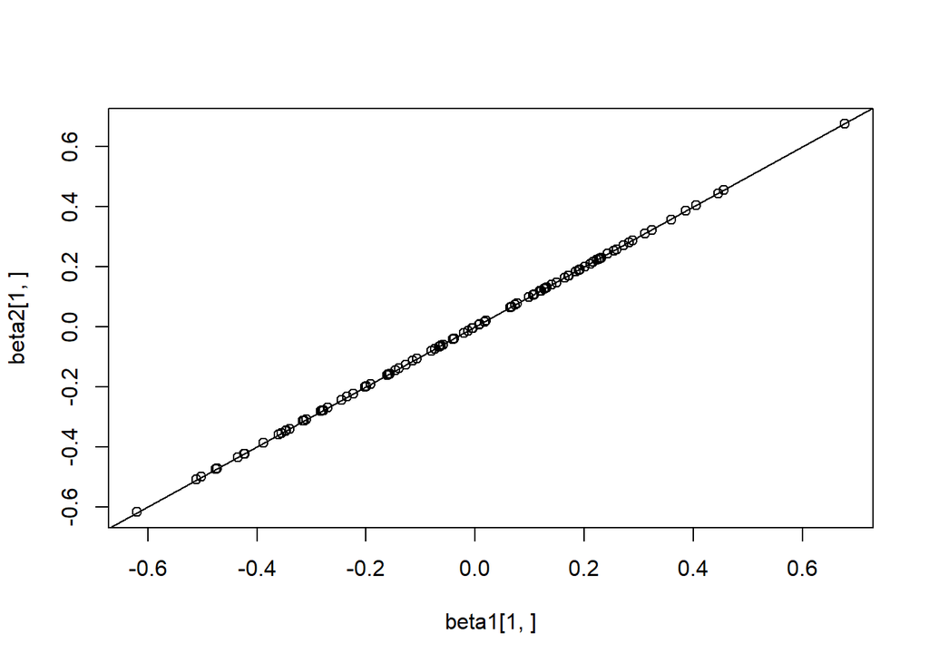

```r
plot(beta1[1,], beta2[1,])
abline(0,1)
```

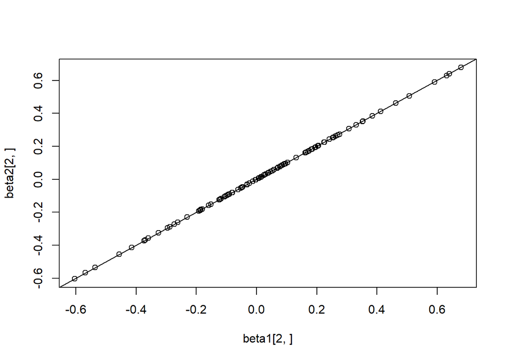

```r
plot(beta1[2,], beta2[2,])
abline(0,1)
```

```r
all.equal(beta1[1,], beta2[1,])
```

```
## [1] "Mean relative difference: 0.003848973"
```

```r
all.equal(beta1[2,], beta2[2,])
```

```
## [1] "Mean relative difference: 0.003778665"
```

```r
microbenchmark(colRidge1(Y, X, lambda), colRidge2(Y, X, lambda), times=10)
```

```
## Unit: microseconds
##                     expr       min        lq       mean    median        uq
##  colRidge1(Y, X, lambda) 59976.401 60366.801 63664.6611 61874.501 62579.101
##  colRidge2(Y, X, lambda)    77.801    79.302    92.4911    81.901   110.401
##        max neval
##  81744.901    10
##    114.101    10
```

- Conclustion: From the plots and the result of all.eqal function, the results from both functions are very close. The Rcpp function (`ColRidge2`) is much faster than the for-loop-in-R function (`colRidge1`).